# More Information on **smoke forecaster**

Sheena Martenies

7/30/2019

# 1 Introduction

# 2 Acronyms

**ED**: Emergency department

**HIA**: Health impact assessment

**HMS**: Hazard mapping system

**PM<sub>2.5</sub>**: Particulate matter with an aerodynamic diameter less than 2.5 $\mu$m

**WF**: Wildfire

# 3 Explanation of Key Terms

**Particulate matter (PM<sub>2.5</sub>):** is particulate matter with an aerodynamic diameter less than 2.5 $\mu$m. PM<sub>2.5</sub> is also sometimes called “fine particulate matter.” Particulate matter consists of all the solid particles or liquid droplets suspended in air. Particulate matter can come from a number of natural and human-made sources, including emissions from vehicles and industrual facilities, windblown dust and sea spray, and wildfires. PM<sub>2.5</sub> is a subset of these naturally-occuring and anthropogenic particles with a diameter smaller than $\frac{1}{30}$th the width of a human hair or smaller (Figure 1). We are concerned about **PM<sub>2.5</sub>** because it has the ability to reach deep into the lungs when inhaled and is known to cause serious health effects, including respiratory and cardiovascular disease among children and older adults. More information on **PM<sub>2.5</sub>** is available from the [US EPA](https://www.epa.gov/pm-pollution/particulate-matter-pm-basics).

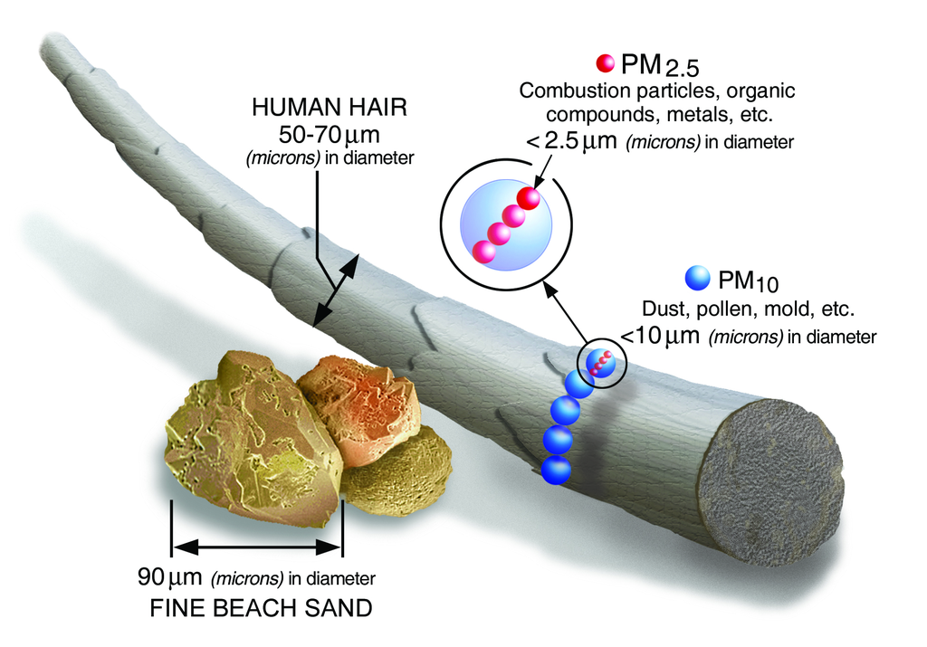

**Figure 1: Size comparisons for particulate matter.** *Image Credit: US EPA*

**Relative Risk (RR):** Relative risk a ratio defined as the risk for an individual who is exposed to a hazard to experience a negative health outcome relative to a person who is not exposed to that hazard (Figure 2). For **smoke forecaster**, we use a relative risk for emergency department visits due to wildfire smoke exposure. For this tool, we consulted epidemiological studies that compared the liklihood that a person who was exposed to wildfire smoke would seek care in an emergency department to the likelihood of an ED visit for an person who was not exposed to wildfire smoke. The ratio of these risks is called the **relative risk** of an ED visit due to wildfire smoke exposure. A relative risk above 1 means that exposed populations are *more likely* to need to visit the ED when exposed to wildfire smoke. The larger the relative risk, the stronger the link is between the hazard (in our case: wildfire smoke) and the outcome (ED visits). The Centers for Disease Control and Prevention has more information on how relative risks are calculated [here](https://www.cdc.gov/csels/dsepd/ss1978/lesson3/section5.html).

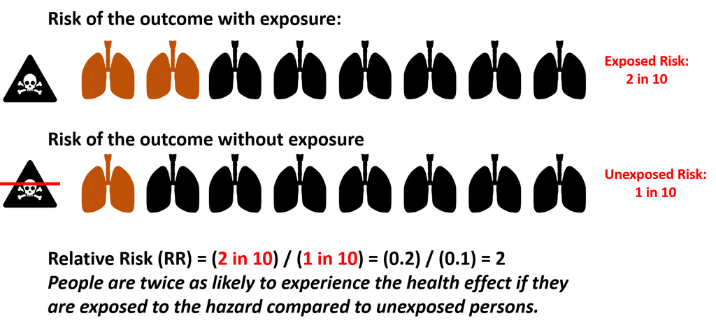

**Figure 2: Relative Risk**

# 4 Health Impact Asssessment

## 4.1 What is health impact assessment?

Health impact assessment (HIA) is a policy- and decision-making tool that provides information on the potential health impacts of an environmental exposure scenario. For **smoke forecaster**, we use HIA to estimate the number of emergency department (ED) visits we might see due to wildfire smoke. This information helps environmental managers, city and county governments, and individuals plan for and make healthier choices during wildfire events.

There are generally two types of HIAs: quantitative and qualitative. Quantitative HIAs tend to focus on health impacts for which we can quantify the relationship between exposure and outcome. **smoke forecaster** uses this type of HIA to estimate how ED visits might increase during wildfire events. ED visits are just one of many potenital health effects associated with wildfires, many of which we cannot yet make quantiative predictions for. These additional health effects might include more frequent rescue inhaler use among people with asthma or less physical activity due to smoke in the air. Therefore, the estimates generated by **smoke forecaster** should be considered a subset of the total health effects.

## 4.2 What information do we need for the **smoke forecaster** HIA?

The HIA used by **smoke forecaster** requires three key pieces of information to make estimates of how many additional emergency department visits we might expect during a wildfire event. We’ve outlined these key inputs below.

**First**, we need to know the concentration of wildfire smoke in the air. Smoke forecaster uses data from the Blue Sky model developed by the U.S. Forest Service to estimate outdoor levels of wildfire smoke on the day of the analysis (i.e., today) and the next day (i.e., tomorrow). These predictions are made using multiple types of data, including:

- wildfire characteristics, such as how much area has burned;
- emissions data, including how much particulate matter and carbon monoxide are emitted from the wildfire;
- and meteorology, including 72-hour data on temperature, wind speed, and humidity.

Blue Sky uses these data in mathematical models that characterize how smoke disperses in the atmosphere. This model is represented in **smoke forecaster** as the “Forecased Smoke” layer in the map. These plumes are an estimate of where smoke is currently located and where it will likely be the next day. The Blue Sky model also gives us an estimate of the concentration of wildfire smoke at the ground level. This is important for the **smoke forecaster** HIA because we are primarily concerned with smoke that people breath in while outside during a wildfire event.

**smoke forecaster** also shows the locations of current wildfires burning in the United States and Canada. This is done using data from the Hazard Mapping System (HMS), which is run by the National Oceanic and Atmospheric Association (NOAA). Each day, NOAA analysts use satellite imagery to identify wildfires and the smoke plumes generated by those fires and create maps that can be downloaded by the public. We incorporate these maps into **smoke forecaster** to help users visualize where wildfires and wildfire smoke are located in North America. The HMS [website](https://www.ospo.noaa.gov/Products/land/hms.html) has more information on how these maps are developed and provides links to download the data.

**Second**, we need to know how many people are exposed to wildfire smoke. Smoke forecaster uses data from the 2015 American Community Survey (an annual survey conducted by the US Census Bureau) to estimate how many people live in each county in the state. To calculate the population-weighted exposure to wildfire smoke, we use the data from the Blue Sky model and population density data from the Socioeconomic Data and Applications Center (SEDAC) at Columbia University.